# Hurricane Helene Spatial Regression

## Introduction

Hurricane Helene struck the Southeastern United States in September, 2024. Storm precipitation totals were measured across the affected area. This project models storm precipitation across one subregion of Hurricane Helene’s path and uses spatial regression methods to generate predictions at unobserved locations. Such predictions can support impact assessment, including estimating potential flood risk and infrastructure damage in areas without direct measurements. The subregion (Figure 1) covers parts of the Florida panhandle, Alabama, Tennessee, Kentucky, Indiana, Georgia, and Illinois.

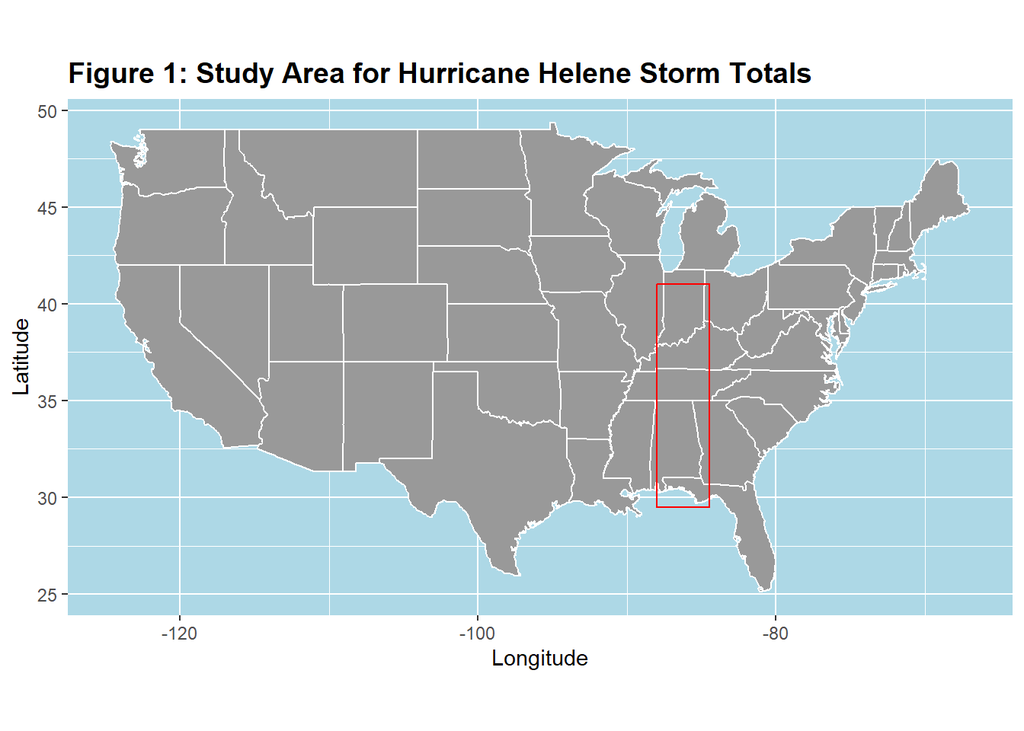

Figure 1: Study Area

## Graphically Exploring the Data

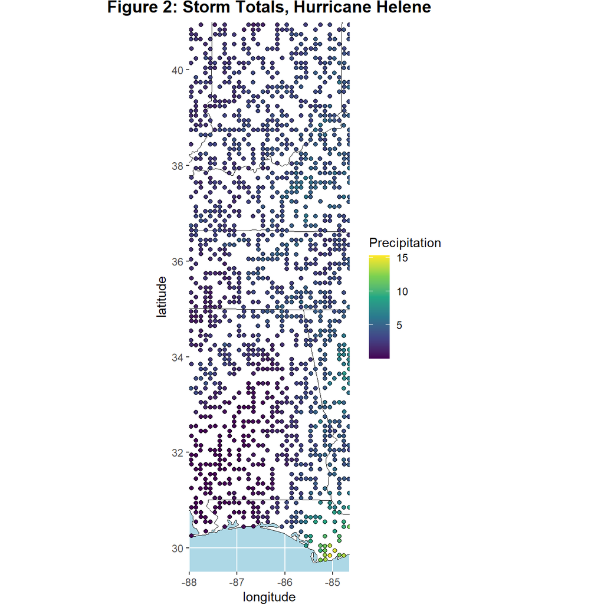

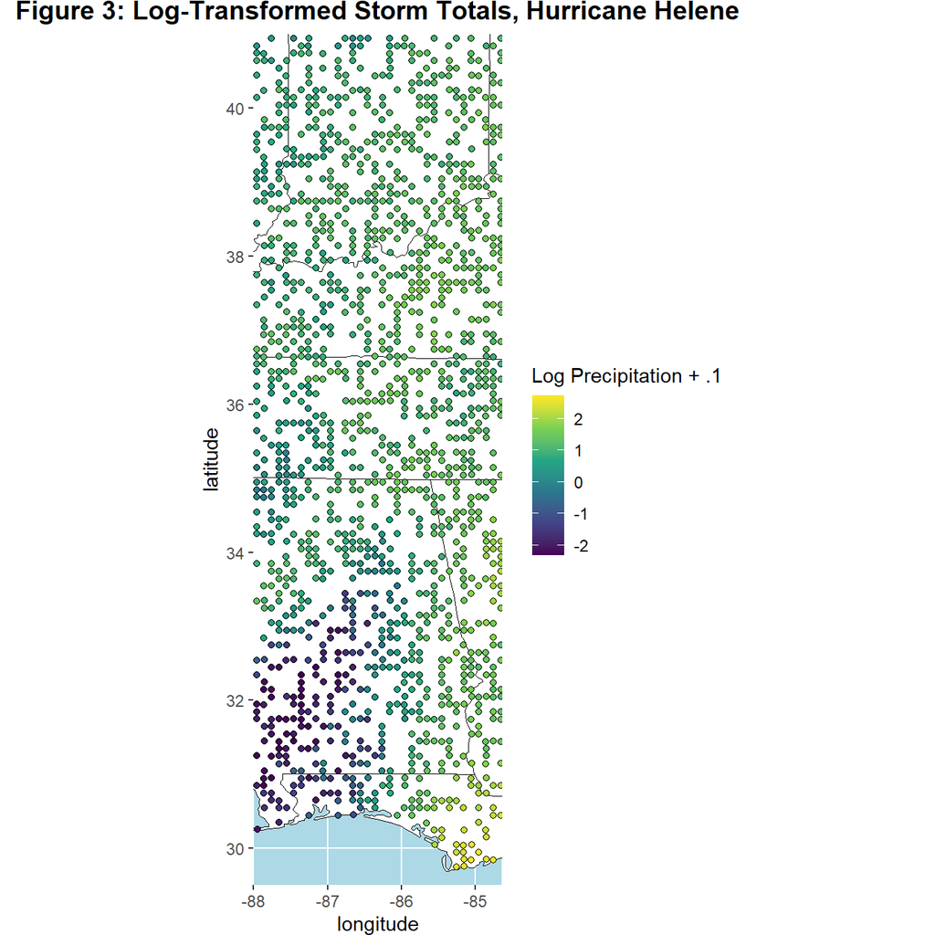

If we plot the storm totals, spatial patterns emerge, suggesting possible spatial dependence. In Figure 2, higher precipitation totals appear in the Florida panhandle and more broadly across the eastern portion of the subregion.

The transformed values (Figure 3) make these spatial patterns more apparent, with lower precipitation concentrated in the southwest and higher values in the southeast.

## Model Fitting

Our regression uses the following covariates, measured at each observation:

- Longitude
- Latitude
- 30 Year Average September Temperature
- 30 Year Average September Precipitation (log transformed)
- Elevation

Covariate data and sources are described in the Data section. To select a model, we compare the following specifications for log-transformed precipitation:

1. log(Precipitation) ~ Latitude + Longitude
2. log(Precipitation) ~ Latitude^2 + Latitude + Longitude^2 + Longitude + Avg. September Temperature
3. log(Precipitation) ~ Latitude^2 + Latitude + Longitude^2 + Longitude + Avg. September Temperature + Elevation + log(Average September Precipitation + .1)
4. log(Precipitation) ~ Latitude^2 + Latitude + Longitude^2 + Longitude + Avg. September Temperature + Elevation + log(Average September Precipitation + .1) + Longitude*Latitude (interaction)

Polynomial terms in latitude and longitude are included to capture broad spatial trends.

To compare these models, we perform 7-fold cross-validation (partitioning the data into seven groups, repeatedly fitting on six and evaluating on the seventh, then averaging the resulting errors). Model performance is assessed using root mean squared error (RMSE).

| Table 1: Model RMSE Model | Table 1: Model RMSE Specification | Table 1: Model RMSE RMSE |
| --- | --- | --- |
| Model 1 | Lat + Lon | 0.7395 |
| Model 2 | Poly(Lat,2) + Poly(Lon,2) + tmean | 0.7132 |
| Model 3 | Poly(Lat,2) + Poly(Lon,2) + tmean + elevation + log(ppt + 0.1) | 0.7127 |
| Model 4 | Model 3 + Lat × Lon | 0.5601 |

Model 4 has the best RMSE value. Before proceeding, we will evaluate for multicolinearity. A covariate which exhibits high colinearity may lead to unstable estimates and poor numerical behavior, particularly when fitting more complex models.

| Table 2: Variance Inflation Factors, Model 4 | Table 2: Variance Inflation Factors, Model 4 GVIF | Table 2: Variance Inflation Factors, Model 4 Df | Table 2: Variance Inflation Factors, Model 4 GVIF^(1/(2*Df)) |
| --- | --- | --- | --- |
| log(ppt + 0.1) | 2.575 | 1 | 1.605 |
| tmean | 66.660 | 1 | 8.165 |
| poly(Lon, 2, raw = TRUE) | 141.304 | 2 | 3.448 |
| poly(Lat, 2, raw = TRUE) | 14194.935 | 2 | 10.915 |
| elevation | 7.939 | 1 | 2.818 |
| Lon:Lat | 7935.626 | 1 | 89.082 |

The interaction term Latitude × Longitude exhibits a very high GVIF, indicating strong collinearity with the polynomial spatial terms. As a result, it is removed from the model.

| Table 3: Regression coefficients for Model 3 | Table 3: Regression coefficients for Model 3 Estimate | Table 3: Regression coefficients for Model 3 Std. Error | Table 3: Regression coefficients for Model 3 Pr(>t) |
| --- | --- | --- | --- |
| (Intercept) | 282.3144 | 159.9986 | 0.0779 |
| log(ppt + 0.1) | 0.6062 | 0.1842 | 0.0010 |
| tmean | 0.1678 | 0.0713 | 0.0187 |
| poly(Lon, 2, raw = TRUE)1 | 7.0480 | 3.7113 | 0.0578 |
| poly(Lon, 2, raw = TRUE)2 | 0.0374 | 0.0215 | 0.0826 |
| poly(Lat, 2, raw = TRUE)1 | 2.1217 | 0.1965 | 0.0000 |
| poly(Lat, 2, raw = TRUE)2 | -0.0261 | 0.0029 | 0.0000 |
| elevation | -0.0006 | 0.0005 | 0.2083 |

| Table 4: Variance Inflation Factors for Model 3 | Table 4: Variance Inflation Factors for Model 3 GVIF | Table 4: Variance Inflation Factors for Model 3 Df | Table 4: Variance Inflation Factors for Model 3 GVIF^(1/(2*Df)) |
| --- | --- | --- | --- |
| log(ppt + 0.1) | 2.538 | 1 | 1.593 |
| tmean | 66.265 | 1 | 8.140 |
| poly(Lon, 2, raw = TRUE) | 1.409 | 2 | 1.089 |
| poly(Lat, 2, raw = TRUE) | 82.827 | 2 | 3.017 |
| elevation | 7.933 | 1 | 2.816 |

If we remove the term and check GVIF numbers for Model 3, no other terms have such an extreme GVIF. Although there is still evidence of colinearity, we do not need to interpret coefficients directly for inference, as the model is primarily used for prediction. It was important to remove the interaction term as the high colinearity caused problems with fitting a universal kriging.

Therefore, moving forward, we will use the following regression model:
$$\log(\text{Prec} + 0.1) =
282.3 + 0.6062\log(\text{ppt} + 0.1) + 0.1678\,\text{tmean}
+ 7.048\,\text{Lon} + 0.03735\,\text{Lon}^2
+ 2.122\,\text{Lat} - 0.02610\,\text{Lat}^2
- 0.0006261\,\text{elevation}$$

## Plotting The Predictions

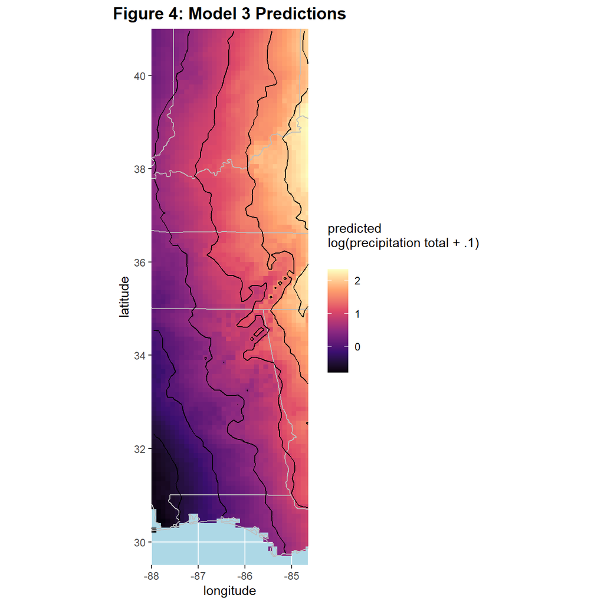

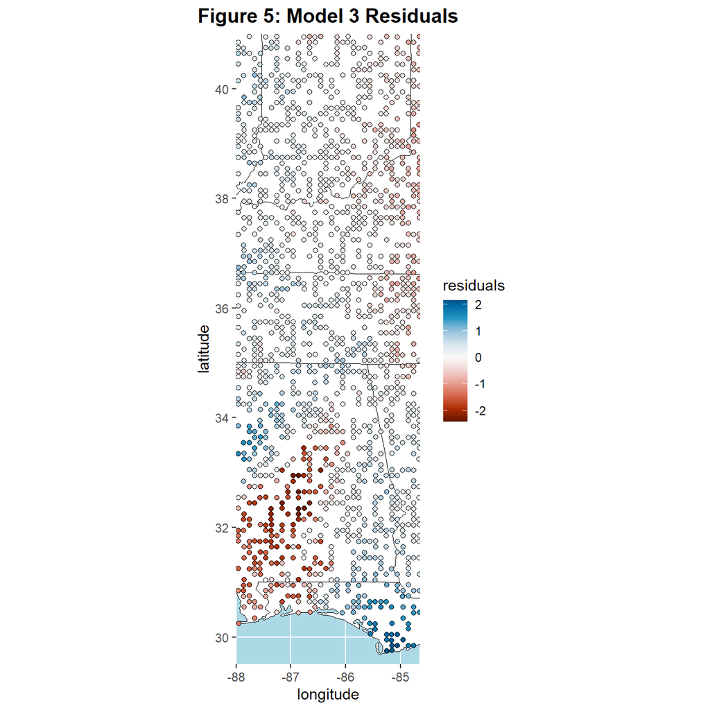

The residuals exhibit clear spatial dependence, with nearby locations tending to have similar errors, indicating that spatial dependence remains unaccounted for by the regression model.

## Picking a kriging model

To account for this remaining spatial dependence, we apply universal kriging. This approach combines the regression mean structure with a spatial covariance model, allowing for improved prediction at unobserved locations.

To model the spatial dependence, we consider several candidate covariance structures: exponential, spherical, Gaussian, and Matérn. These differ in how quickly spatial correlation decays with distance and in the smoothness they impose on the underlying process.

Each model is fit and evaluated using AIC and BIC, which balance goodness of fit with model complexity. The model with the lowest AIC and BIC is selected for subsequent prediction.

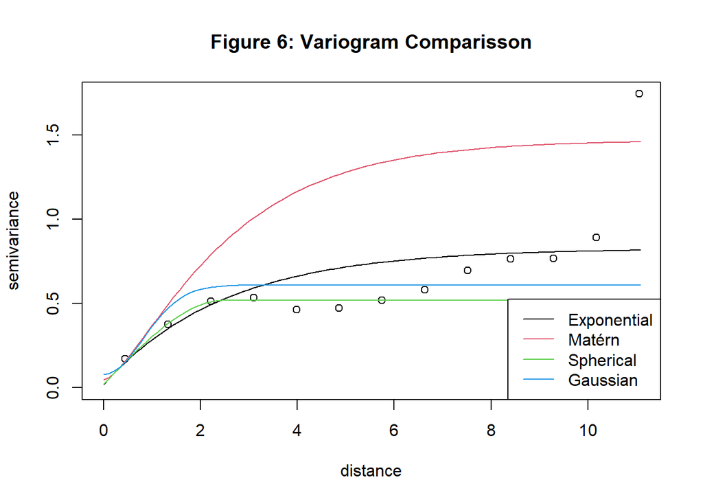

| Table 5: Model comparison for covariance structures Model | Table 5: Model comparison for covariance structures LogLik | Table 5: Model comparison for covariance structures AIC | Table 5: Model comparison for covariance structures BIC |
| --- | --- | --- | --- |
| Exponential | -111.692 | 245.384 | 286.125 |
| Spherical | -109.860 | 241.719 | 282.461 |
| Gaussian | -114.317 | 250.634 | 291.376 |
| Matérn | -108.596 | 241.193 | 285.638 |

The spherical and Matérn models have the lowest AIC and BIC values (Table 5). However, in Figure 6, the Matérn model appears to substantially overestimate both the partial sill and range, resulting in a much smoother variogram than suggested by the data.

This indicates that the Matérn model is likely overfitting the spatial structure. While reducing the number of covariates improved the Matérn fit, it led to worse AIC and BIC values across all models.

Therefore, we will predict using the spherical covariance structure. The fitted spherical covariance model has a partial sill of 0.500, range of 2.508, and nugget of 0.021. The estimated range suggests spatial correlation decays beyond approximately 2.508 degrees.

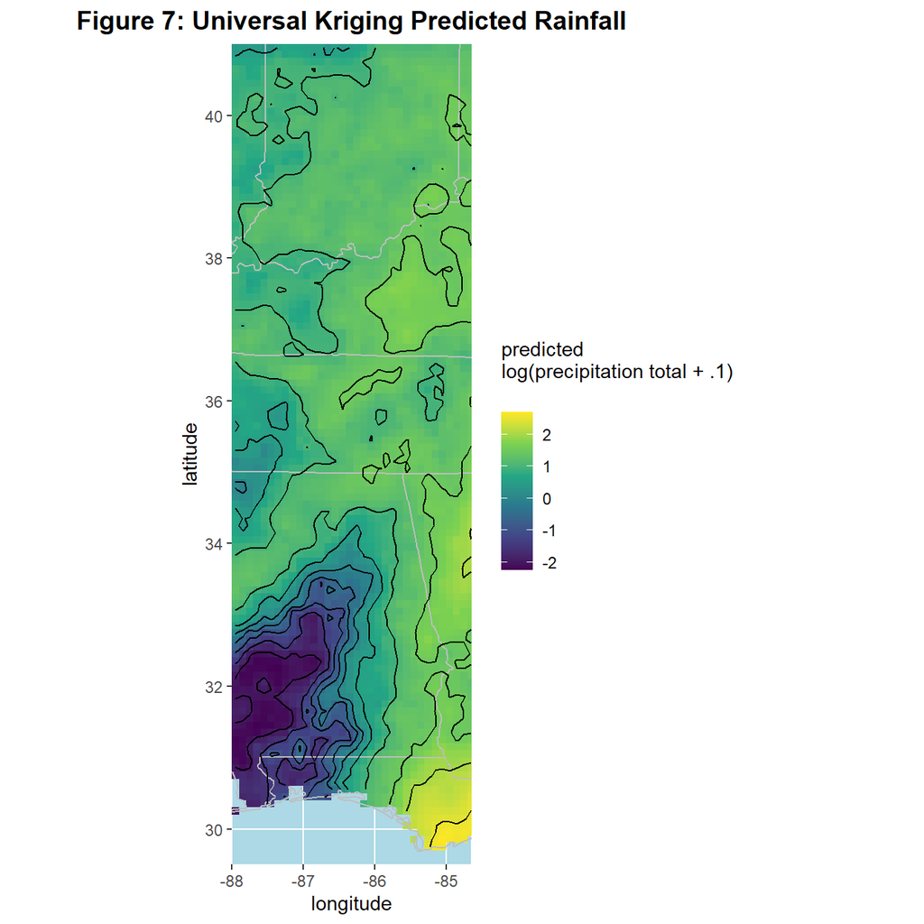

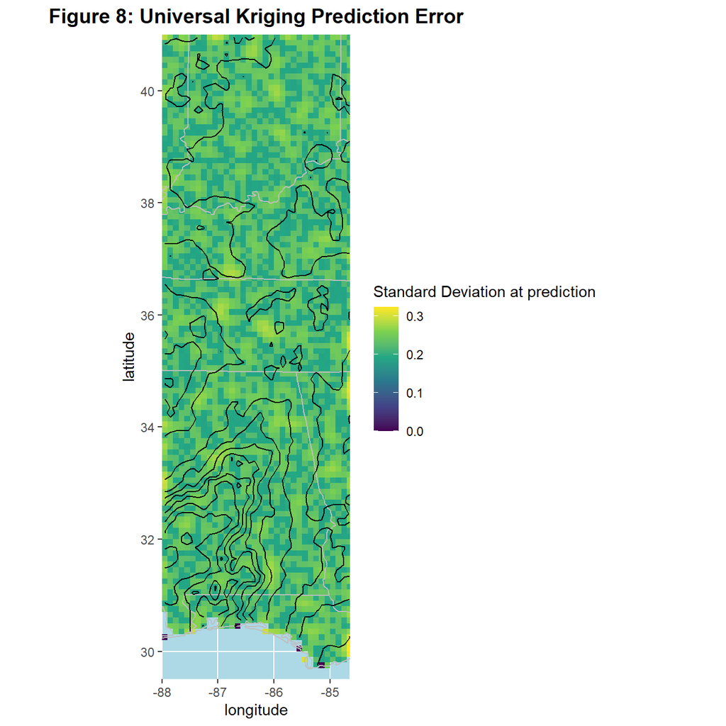

The associated prediction uncertainty (Figure 8) is lowest in regions with dense observations and increases in areas with fewer nearby data points, consistent with the structure of spatial interpolation.

## Data And Code

- Download cleaned dataset (CSV)
- View full analysis code (RMarkdown)
- [Browse raw data files](https://github.com/Gumbo954/Gumbo954.github.io/tree/main/helene/rawdata)